# Reproducible Research: Peer Assessment 1

Chun Lei He

April 7, 2016

## Loading and preprocessing the data

```r
fileurl <- "http://d396qusza40orc.cloudfront.net/repdata%2Fdata%2Factivity.zip"
temp <- tempfile()
wd <- getwd()

download.file(fileurl,temp)
unzip(temp, exdir = wd)
unlink(temp)
```

### Load csv data **activity.csv** and convert dates to **R Date class**

```r
actdata <- read.csv("activity.csv")
actdata$date <- as.Date(actdata$date,"%Y-%m-%d")
head(actdata)
```

```
##   steps       date interval
## 1    NA 2012-10-01        0
## 2    NA 2012-10-01        5
## 3    NA 2012-10-01       10
## 4    NA 2012-10-01       15
## 5    NA 2012-10-01       20
## 6    NA 2012-10-01       25
```

## What is mean total number of steps taken per day?

### 1. Split data by day (date) and calculate total steps on each day

### 2. Plot the histograms

### 3. Calculate mean and median

### First, compute total number of steps per day

```r
totsteps <- tapply(actdata$steps, actdata$date,sum)
```

### Plot histogram of **total number of steps per day**

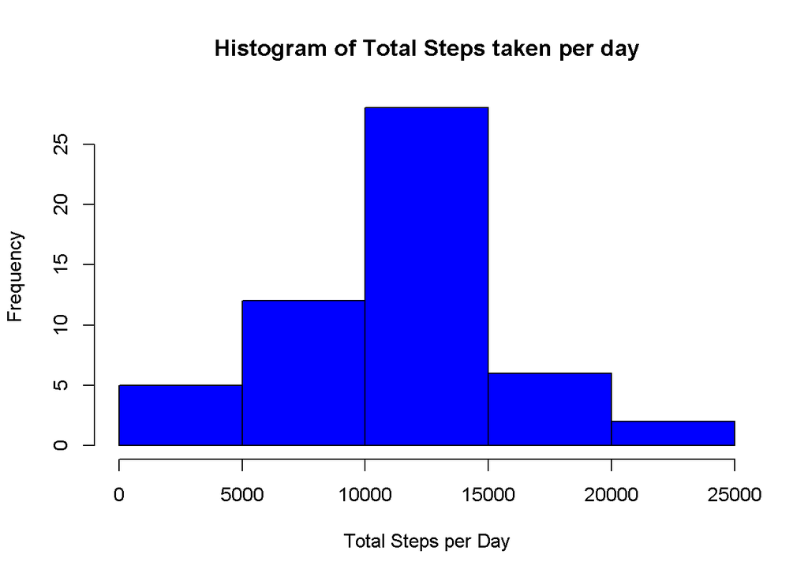

```r
hist(totsteps,col="blue",xlab="Total Steps per Day",
     ylab="Frequency", main="Histogram of Total Steps taken per day")
```

### Compute Mean total steps taken per day

```r
mean(totsteps,na.rm=TRUE)
```

```
## [1] 10766.19
```

### Compute Median total steps taken per day

```r
median(totsteps,na.rm=TRUE)
```

```
## [1] 10765
```

## What is the average daily activity pattern?

### 1. Split data by intervals

### 2. Calculate average of steps in each 5 minutes interval

### 3. Plot 5-minute interval (x-axis) and the average number of steps taken, averaged across all days (y-axis)

### 4. Find the interval that contain maximum number of steps.

### First, compute mean of steps over all days by time interval

```r
meansteps <- tapply(actdata$steps,actdata$interval,
                    mean,na.rm=TRUE)
```

### Then, time series plot of of the 5-minute interval and the average number of steps taken, averaged across all days

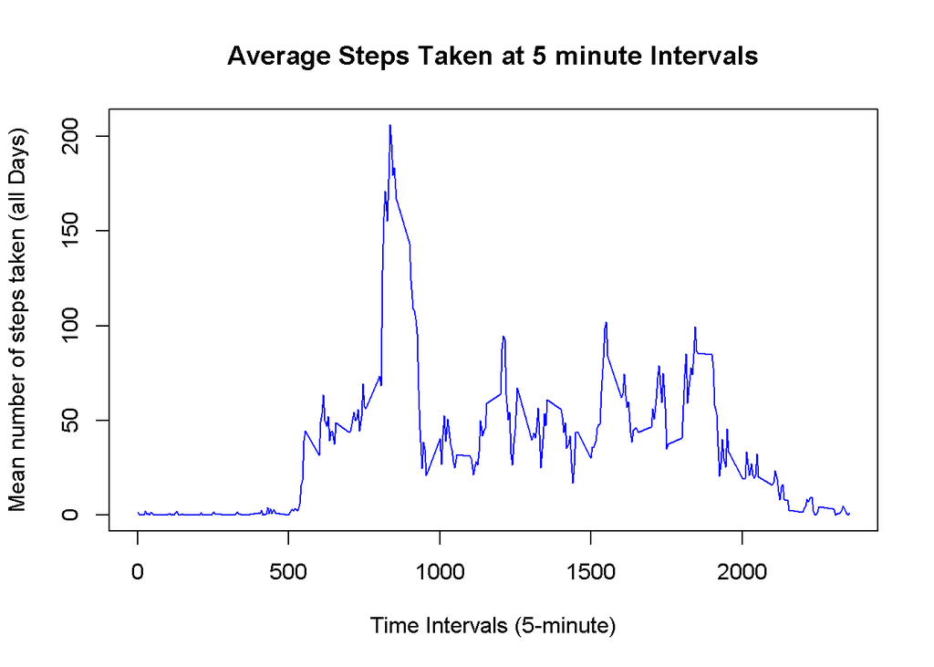

```r
plot(row.names(meansteps),meansteps,type="l",
     xlab="Time Intervals (5-minute)",
     ylab="Mean number of steps taken (all Days)",
     main="Average Steps Taken at 5 minute Intervals",
     col="blue")
```

### Find the time interval that contains maximum average number of steps over all days

```r
interval_num <- which.max(meansteps)
interval_max_steps <- names(interval_num)
interval_max_steps
```

```
## [1] "835"
```

### The 835 minute contains the maximum number of steps on average across all the days

## Imputing missing values

### Compute the number of NA values in the activity dataset

```r
num_na_values <- sum(is.na(actdata))
num_na_values
```

```
## [1] 2304
```

### Fill in missing values using the **average interval value across all days**

```r
na_indices <-  which(is.na(actdata))
imputed_values <- meansteps[as.character(actdata[na_indices,3])]
names(imputed_values) <- na_indices
for (i in na_indices) {
  actdata$steps[i] = imputed_values[as.character(i)]
}
sum(is.na(actdata))
```

```
## [1] 0
```

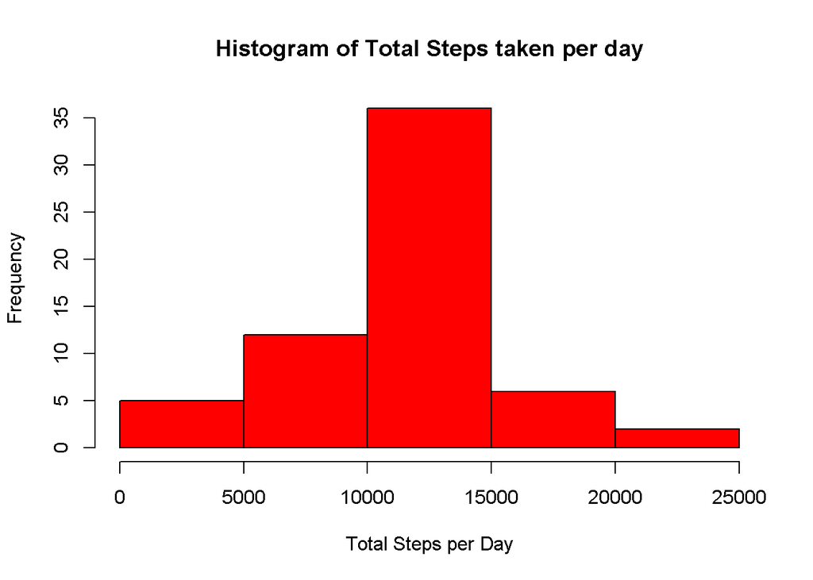

```r
totsteps <- tapply(actdata$steps, actdata$date,sum)
hist(totsteps,col="red",xlab="Total Steps per Day",
     ylab="Frequency", main="Histogram of Total Steps taken per day")
```

## Are there differences in activity patterns between weekdays and weekends?

### 1. Create a new factor variable in the dataset with two levels - “weekday” and “weekend” indicating whether a given date is a weekday or weekend

### 2. Calculate the average of steps on weekdays or weekends (y-axis)

### 3. Make a panel plot containing a time series plot (i.e. type = “l”) of the 5-minute interval (x-axis) and the average number of steps taken on either weekdays or weekends

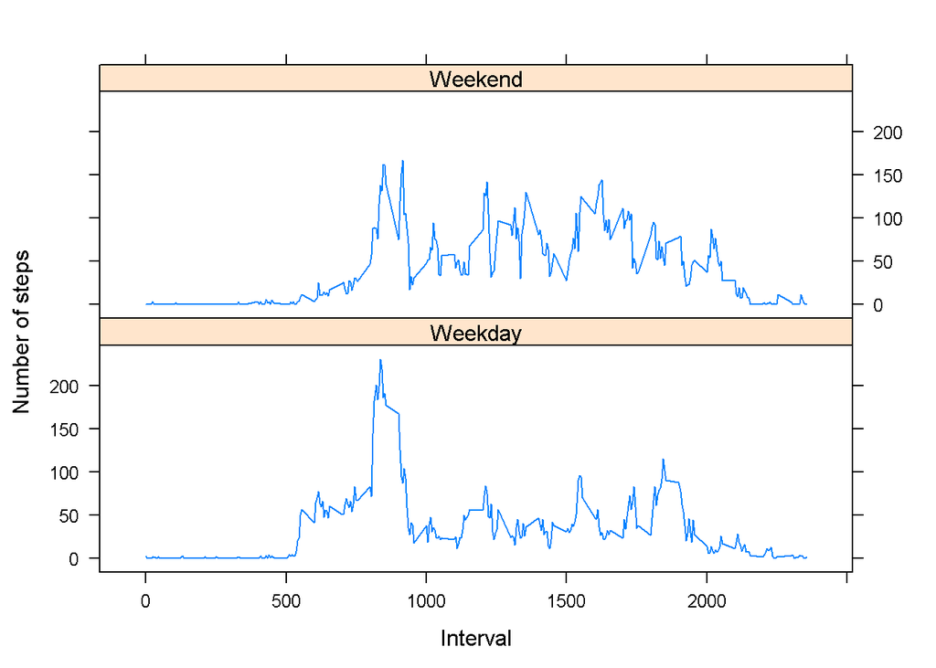

```r
days <- weekdays(actdata$date)
actdata$day_type <- ifelse(days == "Saturday" | days == "Sunday",
                           "Weekend", "Weekday")
meansteps <- aggregate(actdata$steps,
                       by=list(actdata$interval,
                               actdata$day_type),mean)
names(meansteps) <- c("interval","day_type","steps")
xyplot(steps~interval | day_type, meansteps,type="l",
       layout=c(1,2),xlab="Interval",ylab = "Number of steps")
```

### Compute the mean, median, max and min of the steps across all intervals and days by Weekdays/Weekends and show the difference

```r
tapply(meansteps$steps,meansteps$day_type,
function (x) { c(MINIMUM=min(x),MEAN=mean(x),
MEDIAN=median(x),MAXIMUM=max(x))})
```

```
## $Weekday
##   MINIMUM      MEAN    MEDIAN   MAXIMUM
##   0.00000  35.61058  25.80314 230.37820
##
## $Weekend
##   MINIMUM      MEAN    MEDIAN   MAXIMUM
##   0.00000  42.36640  32.33962 166.63915
```